# Natural Gas Price Analysis & Forecasting

### JPMorgan Chase – Quantitative Research Style Project

**Objective:** Analyze historical monthly natural gas prices, identify trends and seasonality, and build a model to estimate prices for any past date and extrapolate one year into the future.

**Data Range:** 31 Oct 2020 – 30 Sep 2024

## 1. Import Required Libraries

We use Python libraries commonly used in quantitative research and data analysis.

```python
import pandas as pd
import numpy as np
import matplotlib.pyplot as plt
from datetime import datetime
from sklearn.linear_model import LinearRegression
```

## 2. Load and Inspect the Data

The dataset contains monthly natural gas prices at month-end. We load the CSV and convert the date column to datetime format.

```python
df = pd.read_csv(r'C:\Users\Bhavesh Mehta\OneDrive\Desktop\Nat_Gas.csv')
df['Dates'] = pd.to_datetime(df['Dates'])
df = df.sort_values('Dates')
df.head()
```

```
C:\Users\Bhavesh Mehta\AppData\Local\Temp\ipykernel_89320\2392129089.py:2: UserWarning: Could not infer format, so each element will be parsed individually, falling back to `dateutil`. To ensure parsing is consistent and as-expected, please specify a format.
  df['Dates'] = pd.to_datetime(df['Dates'])
```

|  | Dates | Prices |
| --- | --- | --- |
| 0 | 2020-10-31 | 10.1 |
| 1 | 2020-11-30 | 10.3 |
| 2 | 2020-12-31 | 11.0 |
| 3 | 2021-01-31 | 10.9 |
| 4 | 2021-02-28 | 10.9 |

## 3. Exploratory Data Analysis (EDA)

We visualize the historical price movement to understand volatility, trend direction, and possible seasonality.

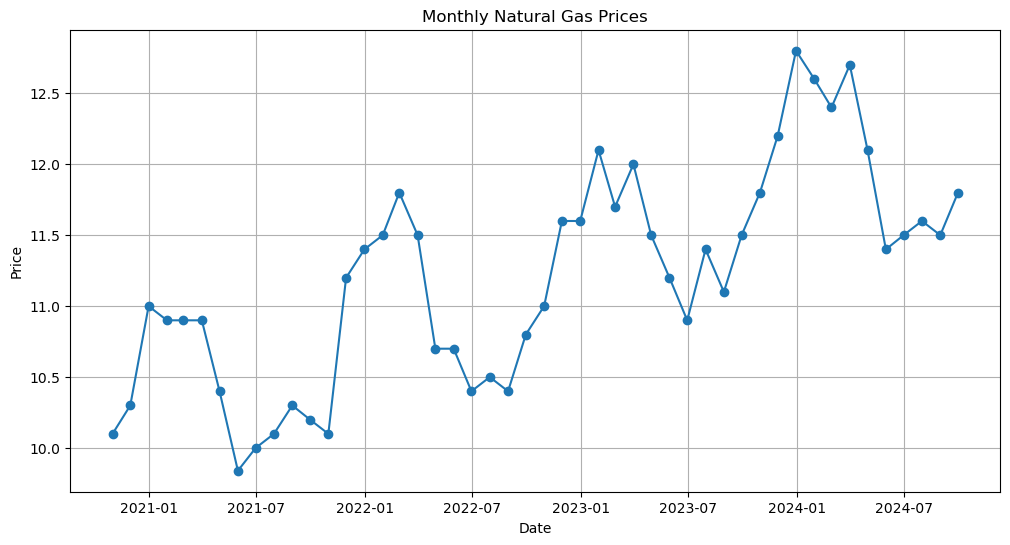

```python
plt.figure(figsize=(12,6))
plt.plot(df['Dates'], df['Prices'], marker='o')
plt.title('Monthly Natural Gas Prices')
plt.xlabel('Date')
plt.ylabel('Price')
plt.grid(True)
plt.show()
```

### Observations

- Prices fluctuate significantly over time
- Sharp increases can be linked to supply constraints or geopolitical events
- Seasonal demand (winter heating) may impact prices

## 4. Feature Engineering

We convert dates into numerical format (ordinal) to allow regression-based modeling.

```python
df['Date_Ordinal'] = df['Dates'].map(datetime.toordinal)
X = df[['Date_Ordinal']]
y = df['Prices']
```

## 5. Model Selection – Linear Regression

We use linear regression as a baseline model to capture the overall trend. This approach is simple, interpretable, and suitable for extrapolation.

```python
model = LinearRegression()
model.fit(X, y)
```

```
LinearRegression()
```

## 6. Price Estimation Function

This function accepts any date and returns an estimated natural gas price. It works for historical dates as well as one year into the future.

```python
def estimate_gas_price(input_date):
    input_date = pd.to_datetime(input_date)
    ordinal_date = input_date.toordinal()
    return model.predict([[ordinal_date]])[0]

# Example usage
estimate_gas_price('2025-06-30')
```

```
np.float64(12.474923364640858)
```

## 7. One-Year Extrapolation

We extend the dataset by one year to visualize projected prices.

```
C:\Users\Bhavesh Mehta\AppData\Local\Temp\ipykernel_89320\1902172000.py:1: FutureWarning: 'M' is deprecated and will be removed in a future version, please use 'ME' instead.
  future_dates = pd.date_range(df['Dates'].max(), periods=13, freq='M')
```

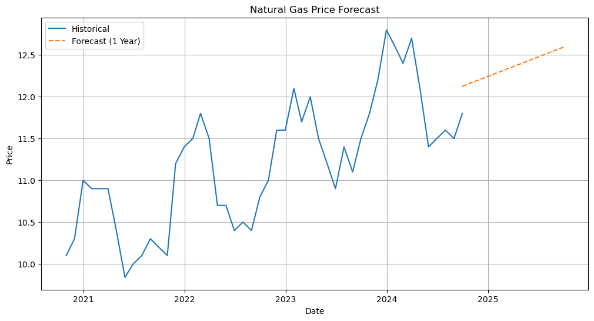

```python
future_dates = pd.date_range(df['Dates'].max(), periods=13, freq='M')
future_ordinals = future_dates.map(datetime.toordinal)
future_prices = model.predict(future_ordinals.values.reshape(-1,1))

plt.figure(figsize=(12,6))
plt.plot(df['Dates'], df['Prices'], label='Historical')
plt.plot(future_dates, future_prices, '--', label='Forecast (1 Year)')
plt.legend()
plt.title('Natural Gas Price Forecast')
plt.xlabel('Date')
plt.ylabel('Price')
plt.grid(True)
plt.show()
```

## 8. Why This Approach Was Used

- **Monthly data** → Avoids noise from daily volatility
- **Regression model** → Transparent and easy to explain to stakeholders
- **Extrapolation** → Suitable for indicative long-term pricing

### Factors Affecting Gas Prices

- Seasonal demand (winter heating)
- Global supply and storage levels
- Geopolitical events
- Energy policy changes

## 9. Conclusion

This notebook demonstrates a structured quantitative approach to commodity price analysis using Python. The model provides quick price estimates for any given date and supports business decisions for long-term storage contracts.